# Mini Projeto 03

### Aprendizado Supervisionado - Professor Mateus Mendelson

##### Integrantes: Nasser Santiago Boan, Emmanuel Moreira, Harlan Martins

Importando bibliotecas e dados

```python
import pandas as pd
import matplotlib.pyplot as plt
from os import listdir
```

```python
print(f'datasets: \n{listdir("data")}')
```

```
datasets:
['heart.csv']
```

```python
original_df = pd.read_csv('data\heart.csv')
```

```python
original_df.head()
```

|  | age | sex | cp | trestbps | chol | fbs | restecg | thalach | exang | oldpeak | slope | ca | thal | target |
| --- | --- | --- | --- | --- | --- | --- | --- | --- | --- | --- | --- | --- | --- | --- |
| 0 | 63 | 1 | 3 | 145 | 233 | 1 | 0 | 150 | 0 | 2.3 | 0 | 0 | 1 | 1 |
| 1 | 37 | 1 | 2 | 130 | 250 | 0 | 1 | 187 | 0 | 3.5 | 0 | 0 | 2 | 1 |
| 2 | 41 | 0 | 1 | 130 | 204 | 0 | 0 | 172 | 0 | 1.4 | 2 | 0 | 2 | 1 |
| 3 | 56 | 1 | 1 | 120 | 236 | 0 | 1 | 178 | 0 | 0.8 | 2 | 0 | 2 | 1 |
| 4 | 57 | 0 | 0 | 120 | 354 | 0 | 1 | 163 | 1 | 0.6 | 2 | 0 | 2 | 1 |

```python
original_df.dtypes
```

```
age           int64
sex           int64
cp            int64
trestbps      int64
chol          int64
fbs           int64
restecg       int64
thalach       int64
exang         int64
oldpeak     float64
slope         int64
ca            int64
thal          int64
target        int64
dtype: object
```

Usaremos as colunas age, chol,thalach e target para esse exercício

```python
df = original_df[['age', 'chol', 'thalach', 'target']].copy()
df.head()
```

|  | age | chol | thalach | target |
| --- | --- | --- | --- | --- |
| 0 | 63 | 233 | 150 | 1 |
| 1 | 37 | 250 | 187 | 1 |
| 2 | 41 | 204 | 172 | 1 |
| 3 | 56 | 236 | 178 | 1 |
| 4 | 57 | 354 | 163 | 1 |

Vamos dar uma olhada nos nossos dados

```python
import plotly.express as px

fig = px.scatter_3d(df, x='age', y='chol', z='thalach',
                    color=df['target'].astype('str'))
fig.update_layout(title='Dataset')
fig.show()
```

[interactive chart not shown]

## Pré-processamento dos dados

### Checagem por dados inválidos

Para verificar se há dados ausentes ou inválidos na nossa base, vamos dropar valores `NaN`.

```python
print(f'Quantidade de dados na base original: {df.shape[0]}')
```

```
Quantidade de dados na base original: 303
```

```python
dfPoints = df.dropna()
```

```python
print(f'Quantidade de dados na base após a remoção dos valores inválidos: {dfPoints.shape[0]}')
```

```
Quantidade de dados na base após a remoção dos valores inválidos: 303
```

Como podemos ver, não houve nenhum dado inválido.

### Normalização dos dados

Esta etapa redimensiona os dados para que os valores variem de 0 até 1. Sabe-se que essa técnica melhora o desempenho dos algoritmos de aprendizado de máquina. Vamos utilizar o método min-max de normalização para executar esta etapa.

```python
def normalize_dataframe(df):
    for column in df.columns:
        maxim = max(df[column])
        minim = min(df[column])

        df[column] = (df[column] - minim)/(maxim - minim)
```

```python
normalize_dataframe(df)
```

```python
fig = px.scatter_3d(df, x='age', y='chol', z='thalach',
                    color=df['target'].astype('int').astype('str')
                   )
fig.update_layout(title='Dataset Normalizado')
fig.show()
```

[interactive chart not shown]

```python
df.head()
```

|  | age | chol | thalach | target |
| --- | --- | --- | --- | --- |
| 0 | 0.708333 | 0.244292 | 0.603053 | 1.0 |
| 1 | 0.166667 | 0.283105 | 0.885496 | 1.0 |
| 2 | 0.250000 | 0.178082 | 0.770992 | 1.0 |
| 3 | 0.562500 | 0.251142 | 0.816794 | 1.0 |
| 4 | 0.583333 | 0.520548 | 0.702290 | 1.0 |

## Conjuntos de treinamento, validação e teste

Essa etapa consiste em separar os dados em três conjuntos: treinamento, validação e teste.

- O conjunto de **treinamento** será utilizado para treinar o modelo. Estes são os dados a partir dos quais o algoritmo aprenderá.
- O conjunto de **validação** será utilizado para avaliar se a rede está ficando viciada (overfitting) no conjunto de treinamento. No momento em que a rede estiver diminuindo seus erros sobre o conjunto de treinamento, mas estiver aumentando seus erros sobre o conjunto de validação, o treinamento deverá ser interrompido. Ou seja, o ponto ideal do treinamento é aquele em que os erros sobre os conjuntos de treinamento e de validação são mínimos ao mesmo tempo.
- O conjunto de **teste** será utilizado para avaliar o modelo. Como esse conjunto não será visto pelo algoritmo durante nenhuma etapa de treinamento, é uma boa maneira de avaliar a capacidade do modelo final em generalizar os padrões aprendidos.

Uma das proporções mais comumentes utilizadas na divisão é 0.7, 0.15, 0.15, ou seja, 70% dos dados são utilizados no conjunto de treinamento, 15% no conjunto de validação e 15% no conjunto de teste.

```python
df.sort_values(by=['target'], inplace=True)
print(f'Distribuição:\n{df["target"].value_counts()/df.shape[0]}')
```

```
Distribuição:
1.0    0.544554
0.0    0.455446
Name: target, dtype: float64
```

A base de dados está razoavelmente equilibrada. Ela possui quase 50% dos dados para cada classe e, portanto, não há necessidade de realizar subamostragem nem sobreamostragem.

Dividiremos o conjunto de dados de maneira equilibrada entre as duas classes. Para isso, utilizaremos o [**StratifiedShuffleSplit**](https://scikit-learn.org/stable/modules/generated/sklearn.model_selection.StratifiedShuffleSplit.html).

Primeiro, vamos pegar o conjunto de treinamento.

```python
from sklearn.model_selection import StratifiedShuffleSplit

X = df[['age', 'chol', 'thalach']]

y = dfPoints['target']

# Vamos utilizar o parâmetro random_state para gerar sempre as mesmas divisões
sss = StratifiedShuffleSplit(n_splits=1, test_size=0.3, random_state=0)
sss.get_n_splits(X, y)

for train_index, remaining_index in sss.split(X, y):
    X_train, X_remaining = X.iloc[train_index], X.iloc[remaining_index]
    y_train, y_remaining = y.iloc[train_index], y.iloc[remaining_index]

X_train.reset_index(inplace=True, drop=True)
y_train.reset_index(inplace=True, drop=True)
X_remaining.reset_index(inplace=True, drop=True)
y_remaining.reset_index(inplace=True, drop=True)
```

```python
print(f'Quantidade de elementos no conjunto de treinamento: {y_train.shape[0]}')

print(f'Distribuição:\n{y_train.value_counts()/y_train.shape[0]}')
```

```
Quantidade de elementos no conjunto de treinamento: 212
Distribuição:
1    0.542453
0    0.457547
Name: target, dtype: float64
```

```python
print(f'Quantidade de elementos restantes: {y_remaining.shape[0]}')

print(f'Distribuição:\n{y_remaining.value_counts()/y_remaining.shape[0]}')
```

```
Quantidade de elementos restantes: 91
Distribuição:
1    0.549451
0    0.450549
Name: target, dtype: float64
```

Agora, vamos pegar os 30% restantes da base de dados e dividir entre os conjuntos de validação e de teste.

```python
# Vamos utilizar o parâmetro random_state para gerar sempre as mesmas divisões
sss = StratifiedShuffleSplit(n_splits=1, test_size=0.5, random_state=0)
sss.get_n_splits(X_remaining, y_remaining)

for valid_index, test_index in sss.split(X_remaining, y_remaining):
    X_valid, X_test = X_remaining.iloc[valid_index], X_remaining.iloc[test_index]
    y_valid, y_test = y_remaining.iloc[valid_index], y_remaining.iloc[test_index]

X_valid.reset_index(inplace=True, drop=True)
y_valid.reset_index(inplace=True, drop=True)
X_test.reset_index(inplace=True, drop=True)
y_test.reset_index(inplace=True, drop=True)
```

```python
print(f'Quantidade de elementos no conjunto de validação: {y_valid.shape[0]}')
print(f'Quantidade de elementos no conjunto de teste: {y_test.shape[0]}')
```

```
Quantidade de elementos no conjunto de validação: 45
Quantidade de elementos no conjunto de teste: 46
```

```python
y_valid.value_counts()
```

```
1    25
0    20
Name: target, dtype: int64
```

```python
y_test.value_counts()
```

```
1    25
0    21
Name: target, dtype: int64
```

Vamos dar uma olhada nos conjuntos que acabamos de criar.

```python
fig = px.scatter_3d(X_train, x='age', y='chol', z='thalach',
                    color=y_train.astype('int32').astype('str'))

fig.update_layout(title='Conjunto de Treinamento')
fig.show()
```

[interactive chart not shown]

```python
fig = px.scatter_3d(X_valid, x='age', y='chol', z='thalach',
                    color=y_valid.astype('int32').astype('str'))
fig.update_layout(title='Conjunto de Validação')
fig.show()
```

[interactive chart not shown]

```python
fig = px.scatter_3d(X_test, x='age', y='chol', z='thalach',
                    color=y_test.astype('int32').astype('str'))
fig.update_layout(title='Conjunto de Teste')
fig.show()
```

[interactive chart not shown]

## Implementação da Rede Neural

Existem muitas arquiteturas diferentes para redes neurais, mas usaremos uma das mais simples aqui: uma rede feed-forward totalmente conectada. Nesta abordagem, a entrada para a rede é processada apenas em uma direção e todos os neurônios de uma camada são conectados a todos os neurônios da camada a seguir.

Para codificar os targets, iremos aplicar [`one-hot encoding`](https://towardsdatascience.com/all-about-categorical-variable-encoding-305f3361fd02) em `target`, gerando duas colunas como targets.

```python
y_train = y_train.astype('int32')
y_valid = y_valid.astype('int32')
y_test = y_test.astype('int32')
```

```python
y_train = pd.get_dummies(y_train, prefix='target')
y_valid = pd.get_dummies(y_valid, prefix='target')
y_test = pd.get_dummies(y_test, prefix='target')
```

```python
import torch.nn as nn
import torch.nn.functional as F

class NeuralNet(nn.Module):
    def __init__(self, input_dim):
        super(NeuralNet, self).__init__()

        self.fc1 = nn.Linear(input_dim, 128)
        self.fc2 = nn.Linear(128, 128)
        self.fc3 = nn.Linear(128, 2)
        self.drop = nn.Dropout(0.3)


    def forward(self, x):
        x = torch.sigmoid(self.fc1(x))
        x = self.drop(x)
        x = torch.sigmoid(self.fc2(x))
        x = self.drop(x)
        x = self.fc3(x)

        return x

input_dim = 3
nn_model = NeuralNet(input_dim)
#nn_model.cuda()
```

Ao utilizar [Cross Entropy Loss](https://pytorch.org/docs/stable/nn.html), nós estamos calculando a probabilidade de cada classe nas saídas. Note que, para isso, não colocamos uma função de ativação na camada de saída da rede, pois esse critério já aplica `LogSoftMax` nos valores recebidos.

Em relação à taxa de aprendizado, é algo que calibramos por meio de múltiplas tentativas. Os valores comumente mais utilizados são 0.1, 0.01 ou 0.001, mas outros valores também podem ser testados.

```python
import numpy as np
import tqdm
import torch.optim as optim
import torch

criterion_t = nn.CrossEntropyLoss()
criterion_v = nn.CrossEntropyLoss()
#optimizer = optim.SGD(nn_model.parameters(), lr=0.001)
optimizer = optim.SGD(nn_model.parameters(), lr=2e-3)
```

```python
def train(model, n_epochs, optimizer, criterion_t, criterion_v,
          X_train, y_train, X_valid, y_valid, out_t_loss, out_v_loss):
    # initialize tracker for minimum validation loss
    model.float()
    valid_loss_min = np.Inf

    for epoch in range(1, n_epochs+1):
        # initialize variables to monitor training and validation loss
        train_loss = torch.tensor([0.0])
        valid_loss = torch.tensor([0.0])

        ###################
        # train the model #
        ###################
        index = 0
        model.train()
        for original_data in X_train:
            original_target = y_train[index]
            target = (original_target == 1).nonzero()[0]

            #data = torch.tensor(()).new_ones((1, 3))
            data = torch.tensor(()).new_ones((1, X_train.shape[1]))

            data[0] = original_data

            optimizer.zero_grad()

            output = model(data)

            # calculate the batch loss
            loss = criterion_t(output, target)
            # backward pass: compute gradient of the loss with respect to model parameters
            loss.backward()
            # perform a single optimization step (parameter update)
            optimizer.step()

            # update training loss
            train_loss += ((1 / (index + 1)) * (loss.data - train_loss))
            index += 1

        ######################
        # validate the model #
        ######################
        index = 0
        model.eval()
        for original_data in X_valid:
            original_target = y_valid[index]
            target = (original_target == 1).nonzero()[0]

            #data = torch.tensor(()).new_ones((1, 3))
            data = torch.tensor(()).new_ones((1, X_valid.shape[1]))
            data[0] = original_data

            # forward pass: compute predicted outputs by passing inputs to the model
            output = model(data)
            # calculate the batch loss
            loss = criterion_v(output, target)

            # update average validation loss
            valid_loss += ((1 / (index + 1)) * (loss.data - valid_loss))
            index += 1

        out_t_loss.append(train_loss.item())
        out_v_loss.append(valid_loss.item())
        ## save the model if validation loss has decreased

        if valid_loss < valid_loss_min:

            print(f'Epoch: {epoch} \tTraining Loss: {train_loss.item()}' +
                  f'\tValid Loss: {valid_loss.item()}\tSaving model...', end='\r')

            valid_loss_min = valid_loss
            torch.save(model.state_dict(), 'best_model.pickle')

    return model
```

```python
# train(model, n_epochs, optimizer, criterion,
#                    X_train, y_train, X_test, y_test, out_t_loss, out_v_loss):
out_t_loss = []
out_v_loss = []
nn_model = train(nn_model, 1000, optimizer, criterion_t, criterion_v,
                 torch.from_numpy(X_train.to_numpy()),
                 torch.from_numpy(y_train.to_numpy()),
                 torch.from_numpy(X_valid.to_numpy()),
                 torch.from_numpy(y_valid.to_numpy()),
                 out_t_loss,
                 out_v_loss)
```

```
Epoch: 997 	Training Loss: 0.6844481229782104	Valid Loss: 0.6797637343406677	Saving model...
```

### Evolução dos erros de treino e validação

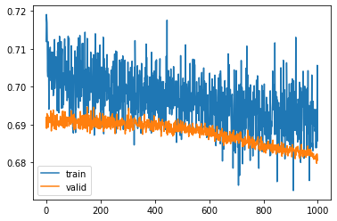

```python
#fig, ax = plt.subplots(1,2)
plt.plot(range(len(out_t_loss)), out_t_loss, label='train')
plt.plot(range(len(out_v_loss)), out_v_loss, label='valid')
plt.legend()
plt.show()
```

```python
def get_accuracy(model, X, y, input_dim):

    model.eval()
    index = 0
    correct = 0
    for original_data in X:
        original_target = y[index]
        target = (original_target == 1).nonzero()[0]

        data = torch.tensor(()).new_ones((1, input_dim))
        data[0] = original_data

        output = model(data)

        # convert output probabilities to predicted class
        _, pred = torch.max(output[0], 0)

        if pred == target:
            correct += 1

        index += 1

    return correct/index
```

Acurácia do modelo

```python
nn_model.load_state_dict(torch.load('best_model.pickle'))

nn_accuracy = get_accuracy(nn_model,
                            torch.from_numpy(X_test.to_numpy()),
                            torch.from_numpy(y_test.to_numpy()),
                          X_test.shape[1])

print(f'Acurácia obtida pela rede neural: {nn_accuracy}')
```

```
Acurácia obtida pela rede neural: 0.5652173913043478
```

Vamos construir a matriz de confusão.

```python
nn_matrix = np.zeros((2, 2))

index = 0

pred_list = []
true_list = []

for original_data in torch.from_numpy(X_test.to_numpy()):
    original_target = torch.from_numpy(y_test.to_numpy())[index]
    target = (original_target == 1).nonzero()[0]
    #print(target.item())
    true_list.append(target.item())

    data = torch.tensor(()).new_ones((1, X_test.shape[1]))
    data[0] = original_data

    output = nn_model(data)

    # convert output probabilities to predicted class
    _, pred = torch.max(output[0], 0)
    #print(pred.item())
    pred_list.append(pred.item())
    nn_matrix[int(target), int(pred)] += 1

    index += 1

nn_matrix
```

```
array([[ 2., 19.],
       [ 1., 24.]])
```

Outras métricas

```python
from sklearn.metrics import classification_report
print(classification_report(true_list, pred_list))
```

```
              precision    recall  f1-score   support

           0       0.67      0.10      0.17        21
           1       0.56      0.96      0.71        25

    accuracy                           0.57        46
   macro avg       0.61      0.53      0.44        46
weighted avg       0.61      0.57      0.46        46
```

# Treinamento com dataset completo

Aqui tenteremos melhorar o modelo utilizando todas as features disponíveis

```python
df_comp = original_df.copy()
df_comp.head()
```

|  | age | sex | cp | trestbps | chol | fbs | restecg | thalach | exang | oldpeak | slope | ca | thal | target |
| --- | --- | --- | --- | --- | --- | --- | --- | --- | --- | --- | --- | --- | --- | --- |
| 0 | 63 | 1 | 3 | 145 | 233 | 1 | 0 | 150 | 0 | 2.3 | 0 | 0 | 1 | 1 |
| 1 | 37 | 1 | 2 | 130 | 250 | 0 | 1 | 187 | 0 | 3.5 | 0 | 0 | 2 | 1 |
| 2 | 41 | 0 | 1 | 130 | 204 | 0 | 0 | 172 | 0 | 1.4 | 2 | 0 | 2 | 1 |
| 3 | 56 | 1 | 1 | 120 | 236 | 0 | 1 | 178 | 0 | 0.8 | 2 | 0 | 2 | 1 |
| 4 | 57 | 0 | 0 | 120 | 354 | 0 | 1 | 163 | 1 | 0.6 | 2 | 0 | 2 | 1 |

```python
from sklearn.preprocessing import OneHotEncoder

enc = OneHotEncoder(sparse=False)
#encode = df_comp[['sex','cp', 'fbs', 'restecg', 'exang', 'thal']]
#enc.fit(X)
one_hot = enc.fit_transform(df_comp[['sex','cp', 'fbs', 'restecg', 'exang', 'thal']].copy())
new_hot = pd.DataFrame(one_hot,columns=enc.get_feature_names())
```

```python
df_comp.drop(['sex','cp', 'fbs', 'restecg', 'exang', 'thal'], axis=1, inplace=True)
```

```python
df_comp = df_comp.merge(new_hot, how='left', on=df_comp.index)
```

```python
df_comp.drop(['key_0'], axis=1, inplace=True)
```

[output not shown]

303 rows × 25 columns

```python
X = df_comp.loc[:, df_comp.columns != 'target']
```

```python
y = df_comp.loc[:, 'target']
```

Normalizar o dataset

```python
normalize_dataframe(df_comp)
df_comp
```

|  | age | trestbps | chol | thalach | oldpeak | slope | ca | target | x0_0 | x0_1 | ... | x2_1 | x3_0 | x3_1 | x3_2 | x4_0 | x4_1 | x5_0 | x5_1 | x5_2 | x5_3 |
| --- | --- | --- | --- | --- | --- | --- | --- | --- | --- | --- | --- | --- | --- | --- | --- | --- | --- | --- | --- | --- | --- |
| 0 | 0.708333 | 0.481132 | 0.244292 | 0.603053 | 0.370968 | 0.0 | 0.00 | 1.0 | 0.0 | 1.0 | ... | 1.0 | 1.0 | 0.0 | 0.0 | 1.0 | 0.0 | 0.0 | 1.0 | 0.0 | 0.0 |
| 1 | 0.166667 | 0.339623 | 0.283105 | 0.885496 | 0.564516 | 0.0 | 0.00 | 1.0 | 0.0 | 1.0 | ... | 0.0 | 0.0 | 1.0 | 0.0 | 1.0 | 0.0 | 0.0 | 0.0 | 1.0 | 0.0 |
| 2 | 0.250000 | 0.339623 | 0.178082 | 0.770992 | 0.225806 | 1.0 | 0.00 | 1.0 | 1.0 | 0.0 | ... | 0.0 | 1.0 | 0.0 | 0.0 | 1.0 | 0.0 | 0.0 | 0.0 | 1.0 | 0.0 |
| 3 | 0.562500 | 0.245283 | 0.251142 | 0.816794 | 0.129032 | 1.0 | 0.00 | 1.0 | 0.0 | 1.0 | ... | 0.0 | 0.0 | 1.0 | 0.0 | 1.0 | 0.0 | 0.0 | 0.0 | 1.0 | 0.0 |
| 4 | 0.583333 | 0.245283 | 0.520548 | 0.702290 | 0.096774 | 1.0 | 0.00 | 1.0 | 1.0 | 0.0 | ... | 0.0 | 0.0 | 1.0 | 0.0 | 0.0 | 1.0 | 0.0 | 0.0 | 1.0 | 0.0 |
| ... | ... | ... | ... | ... | ... | ... | ... | ... | ... | ... | ... | ... | ... | ... | ... | ... | ... | ... | ... | ... | ... |
| 298 | 0.583333 | 0.433962 | 0.262557 | 0.396947 | 0.032258 | 0.5 | 0.00 | 0.0 | 1.0 | 0.0 | ... | 0.0 | 0.0 | 1.0 | 0.0 | 0.0 | 1.0 | 0.0 | 0.0 | 0.0 | 1.0 |
| 299 | 0.333333 | 0.150943 | 0.315068 | 0.465649 | 0.193548 | 0.5 | 0.00 | 0.0 | 0.0 | 1.0 | ... | 0.0 | 0.0 | 1.0 | 0.0 | 1.0 | 0.0 | 0.0 | 0.0 | 0.0 | 1.0 |
| 300 | 0.812500 | 0.471698 | 0.152968 | 0.534351 | 0.548387 | 0.5 | 0.50 | 0.0 | 0.0 | 1.0 | ... | 1.0 | 0.0 | 1.0 | 0.0 | 1.0 | 0.0 | 0.0 | 0.0 | 0.0 | 1.0 |
| 301 | 0.583333 | 0.339623 | 0.011416 | 0.335878 | 0.193548 | 0.5 | 0.25 | 0.0 | 0.0 | 1.0 | ... | 0.0 | 0.0 | 1.0 | 0.0 | 0.0 | 1.0 | 0.0 | 0.0 | 0.0 | 1.0 |
| 302 | 0.583333 | 0.339623 | 0.251142 | 0.786260 | 0.000000 | 0.5 | 0.25 | 0.0 | 1.0 | 0.0 | ... | 0.0 | 1.0 | 0.0 | 0.0 | 1.0 | 0.0 | 0.0 | 0.0 | 1.0 | 0.0 |

303 rows × 25 columns

Separando dados de treino, validação e teste

```python
sss = StratifiedShuffleSplit(n_splits=1, test_size=0.3, random_state=0)
sss.get_n_splits(X, y)

for train_index, remaining_index in sss.split(X, y):
    X_train, X_remaining = X.iloc[train_index], X.iloc[remaining_index]
    y_train, y_remaining = y.iloc[train_index], y.iloc[remaining_index]

X_train.reset_index(inplace=True, drop=True)
y_train.reset_index(inplace=True, drop=True)
X_remaining.reset_index(inplace=True, drop=True)
y_remaining.reset_index(inplace=True, drop=True)
```

```python
# Vamos utilizar o parâmetro random_state para gerar sempre as mesmas divisões
sss = StratifiedShuffleSplit(n_splits=1, test_size=0.5, random_state=0)
sss.get_n_splits(X_remaining, y_remaining)

for valid_index, test_index in sss.split(X_remaining, y_remaining):
    X_valid, X_test = X_remaining.iloc[valid_index], X_remaining.iloc[test_index]
    y_valid, y_test = y_remaining.iloc[valid_index], y_remaining.iloc[test_index]

X_valid.reset_index(inplace=True, drop=True)
y_valid.reset_index(inplace=True, drop=True)
X_test.reset_index(inplace=True, drop=True)
y_test.reset_index(inplace=True, drop=True)
```

One hot encoding

```python
y_train = y_train.astype('int32')
y_valid = y_valid.astype('int32')
y_test = y_test.astype('int32')
```

```python
y_train = pd.get_dummies(y_train, prefix='target')
y_valid = pd.get_dummies(y_valid, prefix='target')
y_test = pd.get_dummies(y_test, prefix='target')
y_train.head()
```

|  | target_0 | target_1 |
| --- | --- | --- |
| 0 | 1 | 0 |
| 1 | 1 | 0 |
| 2 | 0 | 1 |
| 3 | 0 | 1 |
| 4 | 0 | 1 |

Shape dos conjuntos

```python
print(f'X_train shape: {X_train.shape}\nX_valid shape: {X_valid.shape}\n'+
      f'X_test shape: {X_test.shape}')
print('---')
print(f'y_train shape: {y_train.shape}\ny_valid shape: {y_valid.shape}\n'+
      f'y_test shape: {y_test.shape}')
```

[output not shown]

Definição do novo modelo

```python
input_dim = X_train.shape[1]
nn_model = NeuralNet(input_dim)
# loss
criterion_t = nn.CrossEntropyLoss()

criterion_v = nn.CrossEntropyLoss()
# otimizador e learning rate
optimizer = optim.SGD(nn_model.parameters(), lr=2e-3)
```

Treinamento

```python
# train(model, n_epochs, optimizer, criterion,
#                    X_train, y_train, X_test, y_test, out_t_loss, out_v_loss):
out_t_loss = []
out_v_loss = []
nn_model = train(nn_model, 1000, optimizer, criterion_t, criterion_v,
                 torch.from_numpy(X_train.to_numpy()),
                 torch.from_numpy(y_train.to_numpy()),
                 torch.from_numpy(X_valid.to_numpy()),
                 torch.from_numpy(y_valid.to_numpy()),
                 out_t_loss,
                 out_v_loss)
```

```
Epoch: 708 	Training Loss: 0.6033162474632263	Valid Loss: 0.5601012110710144	Saving model...
```

### Evolução dos erros de treino e validação

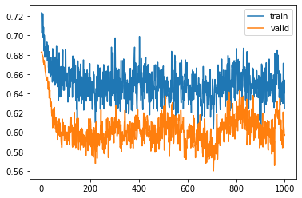

```python
#fig, ax = plt.subplots(1,2)
plt.plot(range(len(out_t_loss)), out_t_loss, label='train')
plt.plot(range(len(out_v_loss)), out_v_loss, label='valid')
plt.legend()
plt.show()
```

Acurácia do modelo

```python
nn_model.load_state_dict(torch.load('best_model.pickle'))

nn_accuracy = get_accuracy(nn_model,
                            torch.from_numpy(X_test.to_numpy()),
                            torch.from_numpy(y_test.to_numpy()),
                          X_test.shape[1])

print(f'Acurácia obtida pela rede neural: {nn_accuracy}')
```

```
Acurácia obtida pela rede neural: 0.6956521739130435
```

Matriz de confusão

```python
nn_matrix = np.zeros((2, 2))

index = 0

pred_list = []
true_list = []

for original_data in torch.from_numpy(X_test.to_numpy()):
    original_target = torch.from_numpy(y_test.to_numpy())[index]
    target = (original_target == 1).nonzero()[0]
    #print(target.item())
    true_list.append(target.item())

    data = torch.tensor(()).new_ones((1, X_test.shape[1]))
    data[0] = original_data

    output = nn_model(data)

    # convert output probabilities to predicted class
    _, pred = torch.max(output[0], 0)
    #print(pred.item())
    pred_list.append(pred.item())
    nn_matrix[int(target), int(pred)] += 1

    index += 1

nn_matrix
```

```
array([[13.,  8.],
       [ 6., 19.]])
```

Outras métricas

```python
from sklearn.metrics import classification_report
print(classification_report(true_list, pred_list))
```

```
              precision    recall  f1-score   support

           0       0.68      0.62      0.65        21
           1       0.70      0.76      0.73        25

    accuracy                           0.70        46
   macro avg       0.69      0.69      0.69        46
weighted avg       0.69      0.70      0.69        46
```

```python
import time

print(time.ctime())
```

[output not shown]